# Midterm

Lindsay Brown

02/12/2021

[output not shown]

Before you get Started

1. Pick a dataset. Ideally, the dataset should be around 2000 rows, and should have both categorical and numeric covariates.

Potential Sources for data: Tidy Tuesday: https://github.com/rfordatascience/tidytuesday

- Note that most of these are .csv files. There is code to load the files from csv for each of the datasets and a short description of the variables, or you can upload the `.csv` file into your `data` folder.

You may use another dataset or your own data, but please make sure it is de-identified.

2. Please schedule a time with Eric or Me to discuss your dataset and research question. We just want to look at the data and make sure that it is appropriate for your question.

Working Together

If you’d like to work together, that is encouraged, but you must divide the work equitably and you must note who worked on what. This is probably easiest as notes in the text. Please let Eric or Me know that you’ll be working together.

No acknowledgements of contributions = -10 points overall.

Please Note

I will take off points (-5 points for each section) if you don’t add observations and notes in your RMarkdown document. I want you to think and reason through your analysis, even if they are preliminary thoughts.

## Define Your Research Question (10 points)

> *Define your research question below. What about the data interests you? What is a specific question you want to find out about the data?*

### **“How does GDP per capita of a country affect the amount of mismanaged plastic waste that each country has?”**

> **Given that the entire world has a serious plastic pollution problem, I thought this dataset might be interesting to explore. I am looking forward to seeing the patterns that emerge as I create the ggplot graphs and can visualize any trends that may exist.**

> *Given your question, what is your expectation about the data?*

> **My expectation for this data is that clear trends will appear with the amount of mismanaged plastic waste based upon GDP per capita of each country. I am hypothesizing that the lower the GDP per capita of the country, the more mismanaged plastic waste that country might have. I am basing this hypothesis upon the knowledge that most lower income countries lack effective waste management infrastructure.**

## Loading the Data (10 points)

> *Load the data below and use `dplyr::glimpse()` or `skimr::skim()` on the data. You should upload the data file into the `data` directory.*

```r
mismanaged_vs_gdp<- readr::read_csv("https://raw.githubusercontent.com/rfordatascience/tidytuesday/master/data/2019/2019-05-21/per-capita-mismanaged-plastic-waste-vs-gdp-per-capita.csv", na="NA")
# save as csv file to Data folder

write_excel_csv(x = mismanaged_vs_gdp ,
                file = "data/mismanaged_vs_gdp.csv")
read_csv(("data/mismanaged_vs_gdp.csv"), na="NA")
```

| Entity | Code | Year | Per capita mismanaged plastic waste (kilograms per person per day) | GDP per capita, PPP (constant 2011 international $) (Rate) | Total population (Gapminder) |
| --- | --- | --- | --- | --- | --- |
| Afghanistan | AFG | 1800 | NA | NA | 3280000 |
| Afghanistan | AFG | 1820 | NA | NA | 3280000 |
| Afghanistan | AFG | 1870 | NA | NA | 4207000 |
| Afghanistan | AFG | 1913 | NA | NA | 5730000 |
| Afghanistan | AFG | 1950 | NA | NA | 8151455 |
| Afghanistan | AFG | 1951 | NA | NA | 8276820 |
| Afghanistan | AFG | 1952 | NA | NA | 8407148 |
| Afghanistan | AFG | 1953 | NA | NA | 8542906 |
| Afghanistan | AFG | 1954 | NA | NA | 8684494 |
| Afghanistan | AFG | 1955 | NA | NA | 8832253 |

[output cut: 9990 more lines]

```r
glimpse(mismanaged_vs_gdp)
```

```
## Rows: 22,204
## Columns: 6
## $ Entity                                                               <chr> …
## $ Code                                                                 <chr> …
## $ Year                                                                 <dbl> …
## $ `Per capita mismanaged plastic waste (kilograms per person per day)` <dbl> …
## $ `GDP per capita, PPP (constant 2011 international $) (Rate)`         <dbl> …
## $ `Total population (Gapminder)`                                       <dbl> …
```

```r
# I first wanted to list all the countries in order to pick a smaller subset of countries to work with
#code from Ted Laderas - help from function assignment
mismanaged_vs_gdp %>% pull(Entity) %>% unique()
```

```
##   [1] "Afghanistan"
##   [2] "Albania"
##   [3] "Algeria"
##   [4] "American Samoa"
##   [5] "Andorra"
##   [6] "Angola"
##   [7] "Anguilla"
##   [8] "Antigua and Barbuda"
##   [9] "Arab World"
##  [10] "Argentina"
##  [11] "Armenia"
##  [12] "Aruba"
##  [13] "Australia"
##  [14] "Austria"
##  [15] "Azerbaijan"
```

[output cut: 268 more lines]

> *If there are any quirks that you have to deal with `NA` coded as something else, or it is multiple tables, please make some notes here about what you need to do before you start transforming the data in the next section.*

> **Make sure your data types are correct!**

## Transforming the data (15 points)

> *If the data needs to be transformed in any way (values recoded, pivoted, etc), do it here. Examples include transforming a continuous variable into a categorical using `case_when()`, etc.*

> *Subset of the data and think of a question to answer the subset*

> **I wanted to start off by cleaning the names of my data, as well as re-naming some of the variables for easier use in coding the ggplots later.**

```r
#Clean names / rename columns
mis_vs_gdp_clean<- clean_names(mismanaged_vs_gdp)
mis_vs_gdp_clean<- mis_vs_gdp_clean %>%
  rename(country = entity, population = total_population_gapminder, gdp =gdp_per_capita_ppp_constant_2011_international_rate,  mpw_kg_person_day= per_capita_mismanaged_plastic_waste_kilograms_per_person_per_day )

#Now that I cleaned my data, I want to save this as my file to use

write_excel_csv(x = mis_vs_gdp_clean,
                file = "data/mis_vs_gdp_clean.csv")

skimr::skim (mis_vs_gdp_clean)
```

Data summary

| Name | mis_vs_gdp_clean |
| --- | --- |
| Number of rows | 22204 |
| Number of columns | 6 |
| _______________________ |  |
| Column type frequency: |  |
| character | 2 |
| numeric | 4 |
| ________________________ |  |
| Group variables | None |

**Variable type: character**

| skim_variable | n_missing | complete_rate | min | max | empty | n_unique | whitespace |
| --- | --- | --- | --- | --- | --- | --- | --- |
| country | 0 | 1 | 4 | 50 | 0 | 283 | 0 |
| code | 0 | 1 | 0 | 8 | 1240 | 239 | 0 |

**Variable type: numeric**

| skim_variable | n_missing | complete_rate | mean | sd | p0 | p25 | p50 | p75 | p100 | hist |
| --- | --- | --- | --- | --- | --- | --- | --- | --- | --- | --- |
| year | 0 | 1.00 | 1959.83 | 51.10 | 1700.00 | 1945.00 | 1973.00 | 1997.00 | 2017.0 | ▁▁▁▂▇ |
| mpw_kg_person_day | 22018 | 0.01 | 0.05 | 0.05 | 0.00 | 0.01 | 0.03 | 0.07 | 0.3 | ▇▂▁▁▁ |
| gdp | 15797 | 0.29 | 14926.10 | 17739.75 | 247.44 | 3021.07 | 8447.26 | 19607.54 | 135318.8 | ▇▂▁▁▁ |
| population | 2123 | 0.90 | 20772028.22 | 84002122.43 | 0.00 | 511000.00 | 3518000.00 | 11253665.00 | 1359368470.0 | ▇▁▁▁▁ |

> **I chose to look at a variety of countries with different income levels. The countries in my subset will be: The United States, Japan, Australia, India, China, Ghana, Indonesia, Tanzania, Brazil, France, Ireland, Iran, Finland and Egypt**

```r
#Creating my subset of countries to work with.
subset_countries <- c("United States", "Japan", "Australia", "India", "China", "Ghana", "Indonesia", "Tanzania", "Brazil","France", "Ireland", "Iran", "Finland","Egypt")

mis_vs_gdp_clean <- mis_vs_gdp_clean %>%
  filter(country %in% subset_countries)


# I removed the "code" variable, as I will not be using it
mis_vs_gdp_clean<- mis_vs_gdp_clean %>%
  select(-code)
```

[output not shown]

> *Show your transformed table here.* Use tools such as `glimpse()`, `skim()` or `head()` to illustrate your point.

```r
glimpse(mis_vs_gdp_clean)
```

```
## Rows: 2,122
## Columns: 5
## $ country           <chr> "Australia", "Australia", "Australia", "Australia",…
## $ year              <dbl> 1700, 1800, 1820, 1821, 1822, 1823, 1824, 1825, 182…
## $ mpw_kg_person_day <dbl> NA, NA, NA, NA, NA, NA, NA, NA, NA, NA, NA, NA, NA,…
## $ gdp               <dbl> NA, NA, NA, NA, NA, NA, NA, NA, NA, NA, NA, NA, NA,…
## $ population        <dbl> 450000, 351014, 334000, 331000, 329000, 329000, 332…
```

```r
skimr::skim(mis_vs_gdp_clean)
```

Data summary

| Name | mis_vs_gdp_clean |
| --- | --- |
| Number of rows | 2122 |
| Number of columns | 5 |
| _______________________ |  |
| Column type frequency: |  |
| character | 1 |
| numeric | 4 |
| ________________________ |  |
| Group variables | None |

**Variable type: character**

| skim_variable | n_missing | complete_rate | min | max | empty | n_unique | whitespace |
| --- | --- | --- | --- | --- | --- | --- | --- |
| country | 0 | 1 | 4 | 13 | 0 | 14 | 0 |

**Variable type: numeric**

| skim_variable | n_missing | complete_rate | mean | sd | p0 | p25 | p50 | p75 | p100 | hist |
| --- | --- | --- | --- | --- | --- | --- | --- | --- | --- | --- |
| year | 0 | 1.00 | 1928.32 | 60.44 | 1700.00 | 1880.00 | 1938.00 | 1980.00 | 2.017000e+03 | ▁▁▅▆▇ |
| mpw_kg_person_day | 2108 | 0.01 | 0.03 | 0.04 | 0.00 | 0.01 | 0.01 | 0.04 | 1.200000e-01 | ▇▂▁▁▁ |
| gdp | 1730 | 0.18 | 20382.41 | 16542.10 | 1361.41 | 5289.46 | 13609.88 | 36233.27 | 6.733529e+04 | ▇▁▅▂▁ |
| population | 56 | 0.97 | 121571641.14 | 233286511.20 | 326000.00 | 5951746.75 | 35008000.00 | 96209849.50 | 1.359368e+09 | ▇▁▁▁▁ |

```r
head(mis_vs_gdp_clean)
```

| country | year | mpw_kg_person_day | gdp | population |
| --- | --- | --- | --- | --- |
| Australia | 1700 | NA | NA | 450000 |
| Australia | 1800 | NA | NA | 351014 |
| Australia | 1820 | NA | NA | 334000 |
| Australia | 1821 | NA | NA | 331000 |
| Australia | 1822 | NA | NA | 329000 |
| Australia | 1823 | NA | NA | 329000 |

> *Are the values what you expected for the variables? Why or Why not?*

> `glimpse()` helped me quickly see my column names, but `skim()` was probably the most helpful as it showed me the missing values for my variable `mpw_kg_person_day` which I was not expecting and lead me to believe that it was a single year that this data was collected for each country.

## Visualizing and Summarizing the Data (15 points)

> *Use `group_by()/summarize()` to make a summary of the data here. The summary should be relevant to your research question*

[output not shown]

| country | mean_gdp |
| --- | --- |
| United States | 46251.256 |
| Ireland | 40295.162 |
| Australia | 36962.696 |
| Finland | 35317.694 |
| France | 34781.529 |
| Japan | 34653.091 |
| Iran | 14957.793 |
| Brazil | 12487.392 |
| Egypt | 8053.203 |
| Indonesia | 7222.276 |

[output cut: 4 more lines]

**What are your findings about the summary? Are they what you expected?**

**I chose to look at the mean gdp for each country and arranged them in descending order.Since there was only one year of data for mismanaged plastic waste per person (kg/day) I thought this would be the most helpful summary. I expected The United States to be the highest GDP, but was unsure where the other countries would fall, overall I found the summary interesting.**

*Make at least two plots that help you answer your question on the transformed or summarized data.*

> The first plot is a box plot to explore our previously summarized data of country and GDP per capita. I thought with the number of years that gdp was available, that this would be a good representation of any skew in the data as well as show the median range for GDP per country.

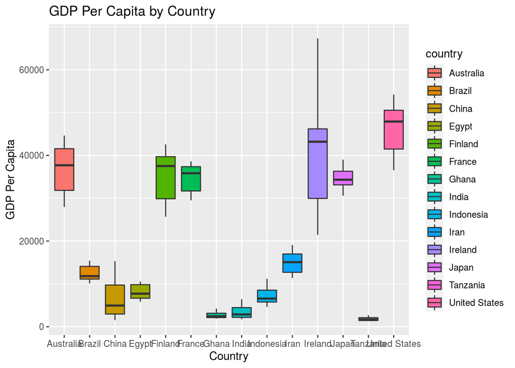

```r
ggplot(mis_vs_gdp_clean) +

  aes(x = country,
      y = gdp,
      fill = country) +

  geom_boxplot() +
  labs(title = "GDP Per Capita by Country",
       x = "Country",
       y = "GDP Per Capita")
```

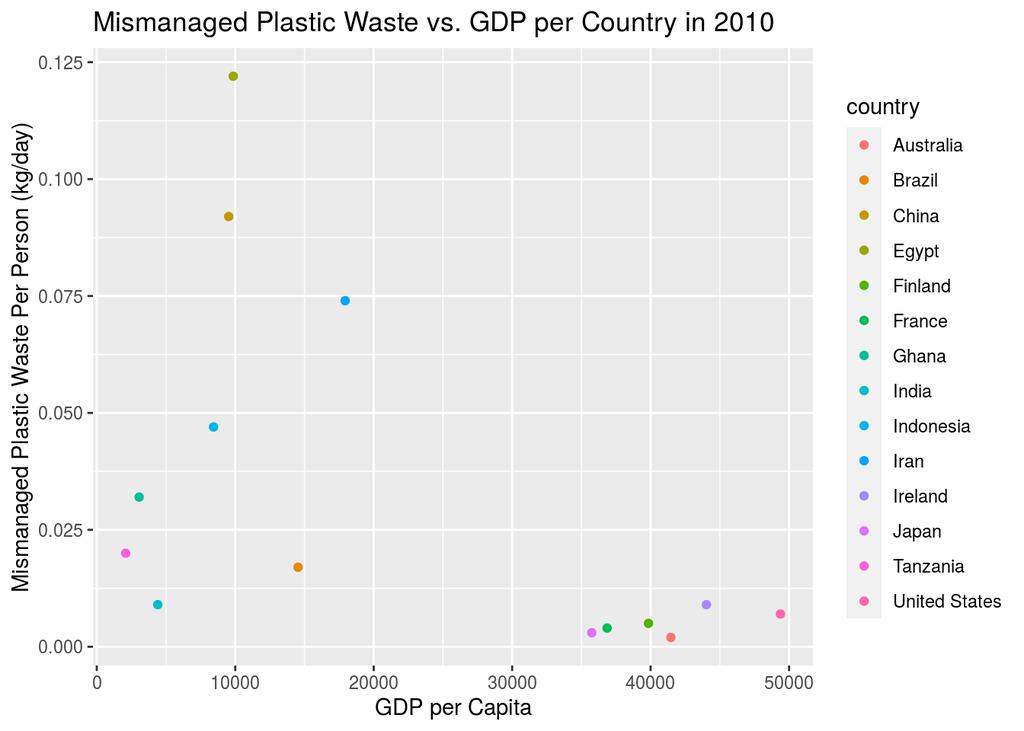

```r
# The only year that kilograms of mismanaged plastic waste per person per day was recorded was 2010, therefore I made a smaller dataset limited to the year 2010
small_set <- mis_vs_gdp_clean%>%
  filter(year==2010)

ggplot(small_set, aes(gdp,mpw_kg_person_day)) +

  geom_point(aes(colour =country)) +
  labs(title = "Mismanaged Plastic Waste vs. GDP per Country in 2010",
       x = "GDP per Capita",
       y = "Mismanaged Plastic Waste Per Person (kg/day)")
```

## Final Summary (10 points)

> *Summarize your research question and findings below.*

> I was dissapointed to find that my main variable of mismanaged plastic waste per person (kg/day) was only available in one year (2010). This was unexpected as the dataset seemed full when intially looking at it. However I made the best of it, and found which ggplots could summarize the data well. The graphs were not quite as exciting as I was hoping for when originally thinking about this dataset.

> To answer my question : **“How does GDP per capita of a country affect the amount of mismanaged plastic waste that each country has?”**  
> It appears when looking at our second plot, that countries with higher GDP per capita had less mismanaged plastic waste. For example The United States, Ireland, Australia and Finland had the highest GDP per capita when we looked at mean GDP, and on the graph they are near the lowest for mismanaged plastic waste.

> *Are your findings what you expected? Why or Why not?*

> These results were consistent with my hypothesis surrounding waste management infrastructure. I was expecting countries with high GDP to have waste management programs in place that would prevent mismanaged plastic waste. However I am curious about countries like Ghana and Tanzania who are the lowest in GDP and also have low amounts of mismanaged plastic waste.

[output not shown]